# Defining Intraindividual Variability in Symptoms

Sum Scores versus Items

```r
# Load packages ----
library(tidyverse)
library(patchwork)
```

### Shalom et al. (2018) definition of intraindividual variability in symptoms

Shalom et al. (2018) define intraindividual variability in symptoms as weekly changes in sum score of multiple item measures, see formula below. When predicting sudden gains by intraindividual variability prior to the gain, the authors mention that this measure was only calculated when **four or more** session by session intervals were available to increase the reliability. As a results sudden gains that occurred early in treatment (before session 5) were excluded from this particular analysis. In studies where a substantial subgroup of participants experience gains early in treatment, this may be problematic. This is of course less problematic when **pretreatment** intraindividual variability is used as a predictor for sudden gains (Shalom et al. 2020).

$$\sum^{s=N}_{s=1}\left(\frac{|\Delta_{s},s+1|}{N}\right)$$

### Create example data (item by item)

Building on results from their earlier study Shalom et al. (2020) investigate **pretreatment and within-treatment** intraindividual variability in the **sum scores** of two symptom measures that were administered weekly: (a) the severity of social anxiety was measured using the 17-item Social Phobia Inventory (SPIN) and (b) depressed mood was measured using the 9-item version of the Patient Health Questionnaire (PHQ-9).

Shalom et al. (2018) definition of intraindividual variability focuses on the severity of the main outcome measure but does not account for **item by item symptom changes**. Depending on the research question and definition of intraindividual variability in symptoms both methods may be valid, but potentially measure different aspects. I demonstrate this problem in the following example:

First, I create a dataset with 5 participants who were assessed with a 2-item measure during 7 sessions.

- `id`: ID variable
- `n`: Indicates an event, in this case “sudden gain”
- `x_s1_i1` - `x_s7_i2`: Item by item measures

```r
# Create data ----
data <- tribble(~id,  ~n, ~x_s1_i1, ~x_s1_i2, ~x_s2_i1, ~x_s2_i2, ~x_s3_i1, ~x_s3_i2, ~x_s4_i1, ~x_s4_i2, ~x_s5_i1, ~x_s5_i2, ~x_s6_i1, ~x_s6_i2, ~x_s7_i1, ~x_s7_i2,
                  1,   5,        3,       3,        3,        2,        3,        2,        3,        3,        2,        3,        1,        0,        0,        0,
                  2,   3,        2,       3,        2,        3,        3,        3,        0,        1,        1,        0,        0,        0,        0,        0,
                  3,  NA,        1,       3,        1,        2,        1,        2,        1,        2,        2,        1,        1,        2,        1,        1,
                  4,   5,        3,       2,        3,        3,        3,        1,        3,        2,        2,        2,        0,        0,        0,        0,
                  5,   6,        2,       2,        1,        3,        3,        1,        2,        2,        3,        1,        2,        2,        0,        0)

data
```

| id | n | x_s1_i1 | x_s1_i2 | x_s2_i1 | x_s2_i2 | x_s3_i1 | x_s3_i2 | x_s4_i1 | x_s4_i2 | x_s5_i1 | x_s5_i2 | x_s6_i1 | x_s6_i2 | x_s7_i1 | x_s7_i2 |
| --- | --- | --- | --- | --- | --- | --- | --- | --- | --- | --- | --- | --- | --- | --- | --- |
| 1 | 5 | 3 | 3 | 3 | 2 | 3 | 2 | 3 | 3 | 2 | 3 | 1 | 0 | 0 | 0 |
| 2 | 3 | 2 | 3 | 2 | 3 | 3 | 3 | 0 | 1 | 1 | 0 | 0 | 0 | 0 | 0 |
| 3 | NA | 1 | 3 | 1 | 2 | 1 | 2 | 1 | 2 | 2 | 1 | 1 | 2 | 1 | 1 |
| 4 | 5 | 3 | 2 | 3 | 3 | 3 | 1 | 3 | 2 | 2 | 2 | 0 | 0 | 0 | 0 |
| 5 | 6 | 2 | 2 | 1 | 3 | 3 | 1 | 2 | 2 | 3 | 1 | 2 | 2 | 0 | 0 |

### Calculating sum scores

Next, I’m calculating sum scores for each participant at every session. Note that this a very basic example data set with no missing values. If there were missing values, this code would have to be changed depending on whether sum scores should be prorated or not.

```r
# Create list of variable names
var_names_item <- c("x_s1_i1", "x_s1_i2",
                    "x_s2_i1", "x_s2_i2",
                    "x_s3_i1", "x_s3_i2",
                    "x_s4_i1", "x_s4_i2",
                    "x_s5_i1", "x_s5_i2",
                    "x_s6_i1", "x_s6_i2",
                    "x_s7_i1", "x_s7_i2")

data_sum <- data %>%
  pivot_longer(cols = all_of(var_names_item),
               names_to = c("measure", "session", "item"),
               names_pattern = "(.)_(.*)_(.*)") %>%
  group_by(id, measure, session) %>%
  mutate(sum = sum(value)) %>%
  select(id, n, measure, session, sum) %>%
  distinct() %>%
  pivot_wider(names_from = c(measure, session), values_from = sum)

data_sum
```

| id | n | x_s1 | x_s2 | x_s3 | x_s4 | x_s5 | x_s6 | x_s7 |
| --- | --- | --- | --- | --- | --- | --- | --- | --- |
| 1 | 5 | 6 | 5 | 5 | 6 | 5 | 1 | 0 |
| 2 | 3 | 5 | 5 | 6 | 1 | 1 | 0 | 0 |
| 3 | NA | 4 | 3 | 3 | 3 | 3 | 3 | 2 |
| 4 | 5 | 5 | 6 | 4 | 5 | 4 | 0 | 0 |
| 5 | 6 | 4 | 4 | 4 | 4 | 4 | 4 | 0 |

### Intraindividual Variability - Sum Scores

This figure shows the trajectories of sum scores, not that `id = 5` (purple line) shows no changes in the sum score from session 1 to session 6.

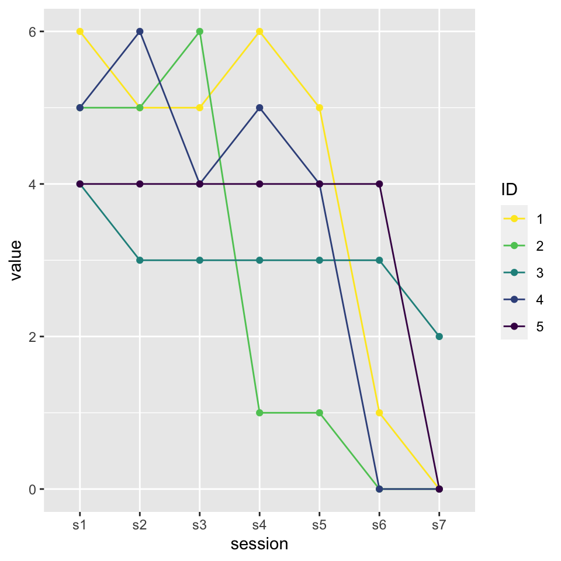

```r
var_names_sum <- paste0("x_s", 1:7)

data_sum %>%
  pivot_longer(all_of(var_names_sum),
               names_to = c("measure", "session"),
               names_pattern = "(.)_(.*)") %>%
  ggplot(aes(x = session, y = value, group = factor(id), colour =factor(id))) +
  geom_line() +
  geom_point() +
  labs(colour = "ID") +
    scale_colour_viridis_d(direction = -1)
```

This code is counting the “variability” in sum scores prior to session ‘n’ using `slice(c(1:unique(n)))`.

```r
data_change_sum <- data_sum %>%
  filter(n > 4) %>%
  pivot_longer(all_of(var_names_sum),
               names_to = c("measure", "session"),
               names_pattern = "(.)_(.*)") %>%
  mutate(session = as.numeric(str_extract(session, "\\d+"))) %>%
  group_by(id, measure) %>%
  slice(c(1:unique(n))) %>%
  mutate(diff_abs = abs(value - lag(value))) %>%
  mutate(lag_value = lag(value),
         diff_value = value - lag_value,
         value_change = sum(diff(sign(diff_value)) != 0, na.rm = T)) %>%
  ungroup() %>%
  select(id, n, measure, value_change) %>%
  distinct()

data_change_sum
```

| id | n | measure | value_change |
| --- | --- | --- | --- |
| 1 | 5 | x | 3 |
| 4 | 5 | x | 3 |
| 5 | 6 | x | 0 |

### Intraindividual Variability - Item by Item

Now we look at “variability” on each item. Note that `id = 5` did not fluctuate on the sum scores but shows changes on the item by item level.

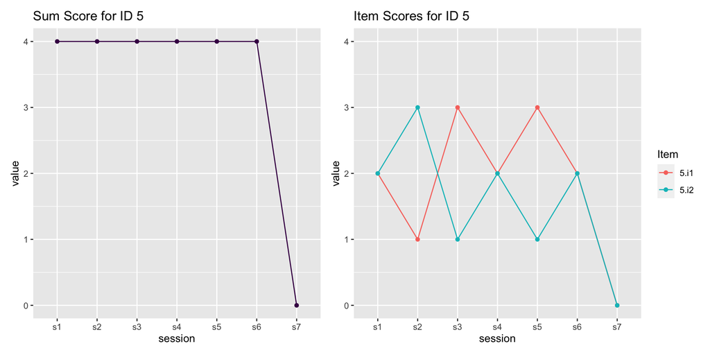

```r
id5_sum <- data_sum %>%
  filter(id == 5) %>%
  pivot_longer(all_of(var_names_sum),
               names_to = c("measure", "session"),
               names_pattern = "(.)_(.*)") %>%
  ggplot(aes(x = session, y = value, group = factor(id), colour =factor(id))) +
  geom_line(colour = "#440154FF") +
  geom_point(colour = "#440154FF") +
  scale_y_continuous(limits = c(0,4)) +
  ggtitle("Sum Score for ID 5") +
  labs(colour = "ID")

id5_item <- data %>%
  filter(id == 5) %>%
  pivot_longer(cols = all_of(var_names_item),
               names_to = c("measure", "session", "item"),
               names_pattern = "(.)_(.*)_(.*)") %>%
  ggplot(aes(x = session, y = value, group = interaction(id, item), colour = interaction(id, item))) +
  geom_line() +
  geom_point() +
  scale_y_continuous(limits = c(0,4)) +
  ggtitle("Item Scores for ID 5") +
  labs(colour = "Item")

id5_sum + id5_item
```

```r
data_change_item <- data %>%
  filter(n > 4) %>%
  pivot_longer(cols = all_of(var_names_item),
               names_to = c("measure", "session", "item"),
               names_pattern = "(.)_(.*)_(.*)") %>%
  mutate(session = as.numeric(str_extract(session, "\\d+")),
         item = as.numeric(str_extract(item, "\\d+"))) %>%
  group_by(id, measure, item) %>%
  slice(c(1:n)) %>%
  mutate(diff_abs = abs(value - lag(value))) %>%
  mutate(lag_value = lag(value),
         diff_value = value - lag_value,
         value_change = sum(diff(sign(diff_value)) != 0, na.rm = T)) %>%
  ungroup() %>%
  select(id, n, measure, item, value_change) %>%
  distinct()

data_change_item
```

| id | n | measure | item | value_change |
| --- | --- | --- | --- | --- |
| 1 | 5 | x | 1 | 1 |
| 1 | 5 | x | 2 | 3 |
| 4 | 5 | x | 1 | 1 |
| 4 | 5 | x | 2 | 3 |
| 5 | 6 | x | 1 | 4 |
| 5 | 6 | x | 2 | 4 |

### Conclusion

This theoretical example demonstrates that Shalom et al. (2018) definition of intraindividual variability might miss aspects of symptom changes on an item by item level. Depending on the definition and research question this could actually be desired. Only of variability on an item by item level is of theoretical interest it would be important to consider an adaptation of the method proposed by Shalom et al. (2018).

For example `id = 5` shows no variability in the sum scores but most variability in item scores compared to other participants. One potential way to address this would be to include item by item changes in the formula instead of changes in sum scores as indicated by the index `i` in $\Delta_{s_i}$, see the adapted formula below:

$$\sum^{s=N}_{s=1}\left(\frac{|\Delta_{s_i},s+1|}{N}\right)$$

# References

Shalom, Jonathan G., Eva Gilboa-Schechtman, Dana Atzil-Slonim, Eran Bar-Kalifa, Ilanit Hasson-Ohayon, Patricia van Oppen, Anton J. L. M. van Balkom, and Idan M. Aderka. 2018. “Intraindividual Variability in Symptoms Consistently Predicts Sudden Gains: An Examination of Three Independent Datasets.” *Journal of Consulting and Clinical Psychology* 86 (11): 892–902. https://doi.org/10.1037/ccp0000344.

Shalom, Jonathan G., Asher Y. Strauss, Jonathan D. Huppert, Gerhard Andersson, Or D. Agassi, and Idan M. Aderka. 2020. “Predicting Sudden Gains Before Treatment Begins: An Examination of Pretreatment Intraindividual Variability in Symptoms.” *Journal of Consulting and Clinical Psychology* 88 (9): 809–17. https://doi.org/10.1037/ccp0000587.